# Project: No-show Appointments Data Analysis

- Introduction
- Data Wrangling
- Exploratory Data Analysis
- Conclusions

## Introduction

In this project, we will be analysing dataset associated with how many patients show up to the doctors after making an appointment. In particular, we will be finding trends among patients who show up timely on appointments and how they differ from those who do not show up.

The original dataset has been sourced from Kaggle Dataset: Medical Appointment No Shows on 29th October 2018.

**"No-show Appointments"** is a dataset that collects information from 100k medical appointments in Brazil and is focused on the question of whether or not patients show up for their appointment. A number of characteristics about the patient are included in each row.

It includes the following columns:

1- PatientId- Identification of a patient

2- AppointmentID- Identification of each appointment

3- Gender- Male or Female

4- ScheduleDay- What day the patient set up their appointment.

5- AppointmentDay- The day of the actual appointment, when they have to visit the doctor.

6- Age- How old is the patient

7- Neighbourhood- Location of the hospital

8- Scholarship- Whether or not the patient is enrolled in Brasilian welfare program Bolsa Família.

9- Hipertension- True or False

10- Diabetes- True or False

11- Alcoholism- True or False

12- Handcap- 4 types of conditions

13-SMS_received- 1 or more messages sent to the patient

The most interesting **question** here is that what factors are important for us to know in order to predict if a patient will show up for their scheduled appointment?

Another **question** to investigate is whether the waiting time (difference between the day appointment was scheduled and when it actually was) impacted the chances of people showing up?

```python
#import libraries
import pandas as pd
import numpy as np
%matplotlib inline
import matplotlib.pyplot as plt
import seaborn as sns
import datetime as dt
```

## Data Wrangling

Load and explore data in detail to find any inconsistencies, errors, missing values and etc.

```python
#load data
df= pd.read_csv('KaggleV2-May-2016.csv')
#Explore data
df.head()
```

|  | PatientId | AppointmentID | Gender | ScheduledDay | AppointmentDay | Age | Neighbourhood | Scholarship | Hipertension | Diabetes | Alcoholism | Handcap | SMS_received | No-show |
| --- | --- | --- | --- | --- | --- | --- | --- | --- | --- | --- | --- | --- | --- | --- |
| 0 | 2.987250e+13 | 5642903 | F | 2016-04-29T18:38:08Z | 2016-04-29T00:00:00Z | 62 | JARDIM DA PENHA | 0 | 1 | 0 | 0 | 0 | 0 | No |
| 1 | 5.589978e+14 | 5642503 | M | 2016-04-29T16:08:27Z | 2016-04-29T00:00:00Z | 56 | JARDIM DA PENHA | 0 | 0 | 0 | 0 | 0 | 0 | No |
| 2 | 4.262962e+12 | 5642549 | F | 2016-04-29T16:19:04Z | 2016-04-29T00:00:00Z | 62 | MATA DA PRAIA | 0 | 0 | 0 | 0 | 0 | 0 | No |
| 3 | 8.679512e+11 | 5642828 | F | 2016-04-29T17:29:31Z | 2016-04-29T00:00:00Z | 8 | PONTAL DE CAMBURI | 0 | 0 | 0 | 0 | 0 | 0 | No |
| 4 | 8.841186e+12 | 5642494 | F | 2016-04-29T16:07:23Z | 2016-04-29T00:00:00Z | 56 | JARDIM DA PENHA | 0 | 1 | 1 | 0 | 0 | 0 | No |

**We wont be investigating PatientId or AppointmentID and won't be necessary for our results.**

```python
df.tail()
```

|  | PatientId | AppointmentID | Gender | ScheduledDay | AppointmentDay | Age | Neighbourhood | Scholarship | Hipertension | Diabetes | Alcoholism | Handcap | SMS_received | No-show |
| --- | --- | --- | --- | --- | --- | --- | --- | --- | --- | --- | --- | --- | --- | --- |
| 110522 | 2.572134e+12 | 5651768 | F | 2016-05-03T09:15:35Z | 2016-06-07T00:00:00Z | 56 | MARIA ORTIZ | 0 | 0 | 0 | 0 | 0 | 1 | No |
| 110523 | 3.596266e+12 | 5650093 | F | 2016-05-03T07:27:33Z | 2016-06-07T00:00:00Z | 51 | MARIA ORTIZ | 0 | 0 | 0 | 0 | 0 | 1 | No |
| 110524 | 1.557663e+13 | 5630692 | F | 2016-04-27T16:03:52Z | 2016-06-07T00:00:00Z | 21 | MARIA ORTIZ | 0 | 0 | 0 | 0 | 0 | 1 | No |
| 110525 | 9.213493e+13 | 5630323 | F | 2016-04-27T15:09:23Z | 2016-06-07T00:00:00Z | 38 | MARIA ORTIZ | 0 | 0 | 0 | 0 | 0 | 1 | No |
| 110526 | 3.775115e+14 | 5629448 | F | 2016-04-27T13:30:56Z | 2016-06-07T00:00:00Z | 54 | MARIA ORTIZ | 0 | 0 | 0 | 0 | 0 | 1 | No |

```python
#Check number of rows and columns in dataset
df.shape
```

```
(110527, 14)
```

```python
#Inspect number of non-null values in each column and their datatypes
df.info()
```

```
<class 'pandas.core.frame.DataFrame'>
RangeIndex: 110527 entries, 0 to 110526
Data columns (total 14 columns):
 #   Column          Non-Null Count   Dtype
---  ------          --------------   -----
 0   PatientId       110527 non-null  float64
 1   AppointmentID   110527 non-null  int64
 2   Gender          110527 non-null  object
 3   ScheduledDay    110527 non-null  object
 4   AppointmentDay  110527 non-null  object
 5   Age             110527 non-null  int64
 6   Neighbourhood   110527 non-null  object
 7   Scholarship     110527 non-null  int64
 8   Hipertension    110527 non-null  int64
 9   Diabetes        110527 non-null  int64
 10  Alcoholism      110527 non-null  int64
 11  Handcap         110527 non-null  int64
 12  SMS_received    110527 non-null  int64
 13  No-show         110527 non-null  object
dtypes: float64(1), int64(8), object(5)
memory usage: 11.8+ MB
```

**ScheduledDay should be in Date Format but is in String**

**AppointmentDay should be in Date Format but is in String**

**No missing values**

**Need to rename some misspelled columns**

**Majority of the columns are int so better to keep 'No-show' column in int as well; 0 and 1 for 'No' and 'Yes' respectively**

```python
#Calculat statistical data like percentile, mean and std of the numerical values of the DataFrame.
df.describe()
```

|  | PatientId | AppointmentID | Age | Scholarship | Hipertension | Diabetes | Alcoholism | Handcap | SMS_received |
| --- | --- | --- | --- | --- | --- | --- | --- | --- | --- |
| count | 1.105270e+05 | 1.105270e+05 | 110527.000000 | 110527.000000 | 110527.000000 | 110527.000000 | 110527.000000 | 110527.000000 | 110527.000000 |
| mean | 1.474963e+14 | 5.675305e+06 | 37.088874 | 0.098266 | 0.197246 | 0.071865 | 0.030400 | 0.022248 | 0.321026 |
| std | 2.560949e+14 | 7.129575e+04 | 23.110205 | 0.297675 | 0.397921 | 0.258265 | 0.171686 | 0.161543 | 0.466873 |
| min | 3.921784e+04 | 5.030230e+06 | -1.000000 | 0.000000 | 0.000000 | 0.000000 | 0.000000 | 0.000000 | 0.000000 |
| 25% | 4.172614e+12 | 5.640286e+06 | 18.000000 | 0.000000 | 0.000000 | 0.000000 | 0.000000 | 0.000000 | 0.000000 |
| 50% | 3.173184e+13 | 5.680573e+06 | 37.000000 | 0.000000 | 0.000000 | 0.000000 | 0.000000 | 0.000000 | 0.000000 |
| 75% | 9.439172e+13 | 5.725524e+06 | 55.000000 | 0.000000 | 0.000000 | 0.000000 | 0.000000 | 0.000000 | 1.000000 |
| max | 9.999816e+14 | 5.790484e+06 | 115.000000 | 1.000000 | 1.000000 | 1.000000 | 1.000000 | 4.000000 | 1.000000 |

**Age has a minimum value of -1 which is invalid so we need to check that.**

**Majority of the patients didnot have hypertension and diabetes, didnot drink alcohol and were not handicapped.**

**Handicap has a maximum value of 4 when it is expected to be 0/1 for handicapped condition to be yes or no.So we need to see that.**

```python
#Check number of patients for each handicap condition
handicap_count=df.Handcap.value_counts()
handicap_count
```

```
0    108286
1      2042
2       183
3        13
4         3
Name: Handcap, dtype: int64
```

```python
#Percentage of total unwanted handicaped conditions (2,3,4)
total= handicap_count[2]+handicap_count[3]+handicap_count[4]
percentage= total/df.Handcap.count()*100
percentage
```

```
0.18004650447401993
```

**As the percentage is extremely small so we can remove those rows with handicap condition 2,3 or 4.**

```python
#Find the number of patients who showed up and who didnot.
df['No-show'].value_counts()
```

```
No     88208
Yes    22319
Name: No-show, dtype: int64
```

**Majority of the patients did show up.**

```python
#Find duplicate rows
df.duplicated().value_counts()
```

```
False    110527
dtype: int64
```

**There are no duplicate values**

[figure not shown]

```python
#Plot histogram for all dataframe
ax= df.hist(bins=25, grid=False, figsize=(20,15), color='#86bf91', zorder=2, rwidth=0.9);
```

**We can see that these results agree with what we saw in the summary statistics.**

**Age is skewed to the right**

**We can see that in age, there is hardly any count after 100 years age, so we can check if they are the outliers by plotting box plot**

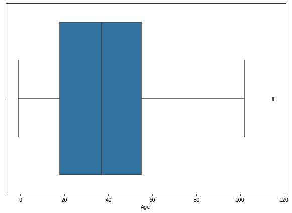

```python
#plot boxplot for age column to see for outliers
plt.figure(figsize=(10,7))
ax = sns.boxplot(x='Age', data=df)
```

**So from this we can see that patients with age greater than 100 are potential outliers so we can remove them**

### Data Cleaning

Clean the data, make any changes required in the data:

1-Rename column names to lowercase,correct misspelled ones (handcap, hipertension), remove any underscores or dashes ( no-show, sms_received).

2- Remove age<0 and age>100

3- Remove handicap = 2,3,4

4- Remove unwanted columns (patiendId, appointmentId)

5- Change data type of scheduledday and appointment day to datetime from object.

6- Change No-show column from object to int; 'No' to 0 and 'Yes' to 1

7- Add a new column, 'weekday' according to the appointment day.

```python
#Change all column names to lowercase to make it easier and not remember what's capital and whats not.
df.rename(columns= lambda x: x.lower(), inplace=True)

#Rename the misspelled column names
df.rename(columns={'hipertension':'hypertension','handcap':'handicap','no-show':'noshow','sms_received':'smsreceived'},inplace=True)

#Check for changes
df.head()
```

|  | patientid | appointmentid | gender | scheduledday | appointmentday | age | neighbourhood | scholarship | hypertension | diabetes | alcoholism | handicap | smsreceived | noshow |
| --- | --- | --- | --- | --- | --- | --- | --- | --- | --- | --- | --- | --- | --- | --- |
| 0 | 2.987250e+13 | 5642903 | F | 2016-04-29T18:38:08Z | 2016-04-29T00:00:00Z | 62 | JARDIM DA PENHA | 0 | 1 | 0 | 0 | 0 | 0 | No |
| 1 | 5.589978e+14 | 5642503 | M | 2016-04-29T16:08:27Z | 2016-04-29T00:00:00Z | 56 | JARDIM DA PENHA | 0 | 0 | 0 | 0 | 0 | 0 | No |
| 2 | 4.262962e+12 | 5642549 | F | 2016-04-29T16:19:04Z | 2016-04-29T00:00:00Z | 62 | MATA DA PRAIA | 0 | 0 | 0 | 0 | 0 | 0 | No |
| 3 | 8.679512e+11 | 5642828 | F | 2016-04-29T17:29:31Z | 2016-04-29T00:00:00Z | 8 | PONTAL DE CAMBURI | 0 | 0 | 0 | 0 | 0 | 0 | No |
| 4 | 8.841186e+12 | 5642494 | F | 2016-04-29T16:07:23Z | 2016-04-29T00:00:00Z | 56 | JARDIM DA PENHA | 0 | 1 | 1 | 0 | 0 | 0 | No |

```python
#Drop the columns not needed
df.drop(['patientid','appointmentid'],axis=1,inplace=True)
```

```python
#Check for changes
df.head()
```

|  | gender | scheduledday | appointmentday | age | neighbourhood | scholarship | hypertension | diabetes | alcoholism | handicap | smsreceived | noshow |
| --- | --- | --- | --- | --- | --- | --- | --- | --- | --- | --- | --- | --- |
| 0 | F | 2016-04-29T18:38:08Z | 2016-04-29T00:00:00Z | 62 | JARDIM DA PENHA | 0 | 1 | 0 | 0 | 0 | 0 | No |
| 1 | M | 2016-04-29T16:08:27Z | 2016-04-29T00:00:00Z | 56 | JARDIM DA PENHA | 0 | 0 | 0 | 0 | 0 | 0 | No |
| 2 | F | 2016-04-29T16:19:04Z | 2016-04-29T00:00:00Z | 62 | MATA DA PRAIA | 0 | 0 | 0 | 0 | 0 | 0 | No |
| 3 | F | 2016-04-29T17:29:31Z | 2016-04-29T00:00:00Z | 8 | PONTAL DE CAMBURI | 0 | 0 | 0 | 0 | 0 | 0 | No |
| 4 | F | 2016-04-29T16:07:23Z | 2016-04-29T00:00:00Z | 56 | JARDIM DA PENHA | 0 | 1 | 1 | 0 | 0 | 0 | No |

```python
#Filter rows for age to be greater than equal to 0 and less than equal to 100
df.query('age>=0 and age<=100', inplace=True)

#Check for changes
df['age'].value_counts()
```

```
0      3539
1      2273
52     1746
49     1652
53     1651
       ...
96       17
97       11
98        6
100       4
99        1
Name: age, Length: 101, dtype: int64
```

```python
#Filter rows for handicap condition to be equal to 0 or 1 only
df.query('handicap==0 | handicap==1', inplace=True)

#Check for changes
df.handicap.value_counts()
```

```
0    108282
1      2038
Name: handicap, dtype: int64
```

```python
#change string to datetime formats of the scheduledday column and appointmentday column and remove timestamps
df['scheduledday']=pd.to_datetime(df['scheduledday']).astype(str).apply(lambda x: x.split(" ")[0])
df['scheduledday']=pd.to_datetime(df['scheduledday'])
df['appointmentday']=pd.to_datetime(df['appointmentday']).astype(str).apply(lambda x: x.split(" ")[0])
df['appointmentday']=pd.to_datetime(df['appointmentday'])

#Check for changes
df.tail()
```

|  | gender | scheduledday | appointmentday | age | neighbourhood | scholarship | hypertension | diabetes | alcoholism | handicap | smsreceived | noshow |
| --- | --- | --- | --- | --- | --- | --- | --- | --- | --- | --- | --- | --- |
| 110522 | F | 2016-05-03 | 2016-06-07 | 56 | MARIA ORTIZ | 0 | 0 | 0 | 0 | 0 | 1 | No |
| 110523 | F | 2016-05-03 | 2016-06-07 | 51 | MARIA ORTIZ | 0 | 0 | 0 | 0 | 0 | 1 | No |
| 110524 | F | 2016-04-27 | 2016-06-07 | 21 | MARIA ORTIZ | 0 | 0 | 0 | 0 | 0 | 1 | No |
| 110525 | F | 2016-04-27 | 2016-06-07 | 38 | MARIA ORTIZ | 0 | 0 | 0 | 0 | 0 | 1 | No |
| 110526 | F | 2016-04-27 | 2016-06-07 | 54 | MARIA ORTIZ | 0 | 0 | 0 | 0 | 0 | 1 | No |

```python
#Change no-show column's 'No' to 0 and 'Yes' to 1 for easy working and visualisation in graphs
df['noshow'].replace(to_replace=['No', 'Yes'], value=[0, 1], inplace=True)
df.head()
```

|  | gender | scheduledday | appointmentday | age | neighbourhood | scholarship | hypertension | diabetes | alcoholism | handicap | smsreceived | noshow |
| --- | --- | --- | --- | --- | --- | --- | --- | --- | --- | --- | --- | --- |
| 0 | F | 2016-04-29 | 2016-04-29 | 62 | JARDIM DA PENHA | 0 | 1 | 0 | 0 | 0 | 0 | 0 |
| 1 | M | 2016-04-29 | 2016-04-29 | 56 | JARDIM DA PENHA | 0 | 0 | 0 | 0 | 0 | 0 | 0 |
| 2 | F | 2016-04-29 | 2016-04-29 | 62 | MATA DA PRAIA | 0 | 0 | 0 | 0 | 0 | 0 | 0 |
| 3 | F | 2016-04-29 | 2016-04-29 | 8 | PONTAL DE CAMBURI | 0 | 0 | 0 | 0 | 0 | 0 | 0 |
| 4 | F | 2016-04-29 | 2016-04-29 | 56 | JARDIM DA PENHA | 0 | 1 | 1 | 0 | 0 | 0 | 0 |

```python
#Add a column 'weekday' for keeping track of the day of the appointment day
df['weekday'] = df['appointmentday'].apply(lambda x: dt.datetime.strftime(x, '%A'))
#Check for changes
df.head()
```

|  | gender | scheduledday | appointmentday | age | neighbourhood | scholarship | hypertension | diabetes | alcoholism | handicap | smsreceived | noshow | weekday |
| --- | --- | --- | --- | --- | --- | --- | --- | --- | --- | --- | --- | --- | --- |
| 0 | F | 2016-04-29 | 2016-04-29 | 62 | JARDIM DA PENHA | 0 | 1 | 0 | 0 | 0 | 0 | 0 | Friday |
| 1 | M | 2016-04-29 | 2016-04-29 | 56 | JARDIM DA PENHA | 0 | 0 | 0 | 0 | 0 | 0 | 0 | Friday |
| 2 | F | 2016-04-29 | 2016-04-29 | 62 | MATA DA PRAIA | 0 | 0 | 0 | 0 | 0 | 0 | 0 | Friday |
| 3 | F | 2016-04-29 | 2016-04-29 | 8 | PONTAL DE CAMBURI | 0 | 0 | 0 | 0 | 0 | 0 | 0 | Friday |
| 4 | F | 2016-04-29 | 2016-04-29 | 56 | JARDIM DA PENHA | 0 | 1 | 1 | 0 | 0 | 0 | 0 | Friday |

## Exploratory Data Analysis

*Dependent Variable:*

1-noshow

*Independent Variables:*

1- gender

2-hypertension

3- alcoholism

4- diabetes

5-age

6- smsreceived

7- handicap

8- scheduledday

9-appointmentday

10- neighbourhood

11- scholarship

### Research Question 1

**What factors are important for us to know in order to predict if a patient will show up for their scheduled appointment?**

We will address this question by computing statistics and creating visualisations. Look at various independent variables, one at a time and see how it effects the dependent variable (noshow).

```python
#Plot the Count Plot
def plotCountPlot(feature, hue,title,labels):
  ax = sns.countplot(x=feature,hue=hue, data=df)
  ax.set_title(title)
  x_ticks_labels=labels
  ax.set_xticklabels(x_ticks_labels)
  plt.show()
```

```python
#Plot the bar plot
def plotBar(x,title):
  ax = sns.barplot(x=x.index, y=x)
  ax.set_title(title)
  ax.set_ylabel('Percentage')
```

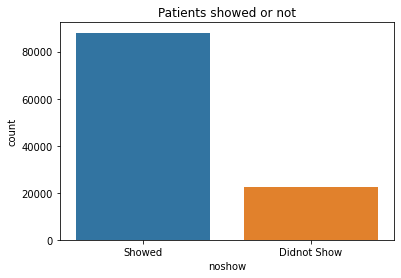

```python
#Investigate the dependent variable- noshow
#Plot the total number of patients that showed up and not
plotCountPlot(df.noshow,None,'Patients showed or not',['Showed','Didnot Show'])
```

**This graph shows that majority of the patients showed up to the doctors.**

**Gender**

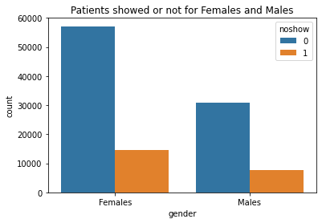

```python
#Plot chart for the number of females and males that showed up and didnot show up
plotCountPlot(df.gender,df.noshow,'Patients showed or not for Females and Males',['Females','Males'])
```

**This graph shows that for both females and males, more patients showed up than not showing up.**

**This shows that more females showed up than males but to confirm this and see if the gender has an effect on the results, we need to compare the proportion of females and males that showed up.**

```
gender
F    65.013597
M    34.986403
Name: age, dtype: float64
```

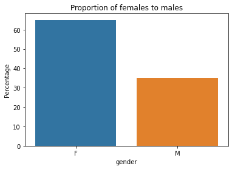

```python
#Find percentage of males and females
males_females_ratio=df.groupby('gender')['age'].count()/df.age.count()*100;
print(males_females_ratio);
#Plot Graph for this proportion
plotBar(males_females_ratio, 'Proportion of females to males');
```

**This shows that there is a greater number of females (around 65%) to number of males (around 35%) so that might be the reason that the above graph showed that more females showed up than males.**

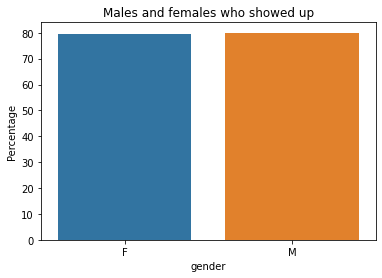

```python
#Find proportion of males and females that showed
df_gender_ratio= df[df.noshow == 0].groupby(['gender']).size()/df.groupby(['gender']).size()*100

#Plot proportion of males and females that showed up
plotBar(df_gender_ratio,'Males and females who showed up')
```

**This chart shows that almost equal proportion of males and females actually showed up. So gender doesnot have an effect on the results.**

**Hypertension**

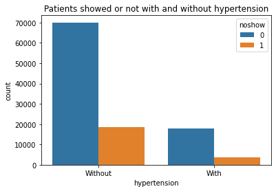

```python
#Plot graph of patients with and without hypertension that showed up and not
plotCountPlot(df.hypertension,df.noshow,"Patients showed or not with and without hypertension",['Without','With'])
```

**This graph shows that in either case, with and without hypertension, more patients showed up. So to better investgate whether hypertension has an effect on people showing up, we need to see the proportion of the individuals that show up with or without hypertension.**

```
hypertension
0    79.090345
1    82.740041
dtype: float64
```

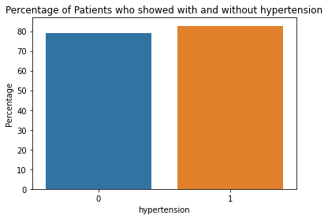

```python
#Find percentage of patients who showed up, grouped based on the hypertension
df_hypertension_ratio= df[df.noshow == 0].groupby(['hypertension']).size()/df.groupby(['hypertension']).size()*100
print(df_hypertension_ratio)

#Plot graph for this ratio
plotBar(df_hypertension_ratio,'Percentage of Patients who showed with and without hypertension')
```

**This graph shows that around 79% of the individuals without hypertension show up while around 83% of the individuals with hypertension show up. So it means that people with hypertension have a greater propbability of showing up to the appointments. So hypertension can be one of the factors to be used to predict whether the patient will show up or not.**

**Alocoholism**

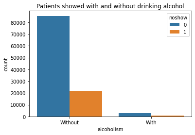

```python
#Plot graph of patients with and without drinking alcohol that showed up and not
plotCountPlot(df.alcoholism,df.noshow,"Patients showed with and without drinking alcohol",['Without','With'])
```

**This graph shows that in either case, with and without drinking alcohol, more patients showed up. So to better investgate whether alcoholism has an effect on people showing up, we need to see the proportion of the individuals that show up with or without drinking alcohol**

```
alcoholism
0    79.807045
1    79.862768
dtype: float64
```

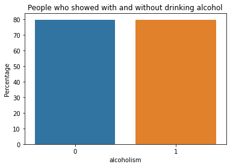

```python
#Find percentage of patients who showed up, grouped based on the alcoholism
df_alcohol_ratio= df[df.noshow == 0].groupby(['alcoholism']).size()/df.groupby(['alcoholism']).size()*100
print(df_alcohol_ratio)

#Plot this result
plotBar(df_alcohol_ratio,'People who showed with and without drinking alcohol')
```

**This graph shows that around equal proportion (79%) of individuals showed up whether they drank alcohol or not.**

**So this factor cannot be used to predict wether the patient will show up or not**.

**Scholarship**

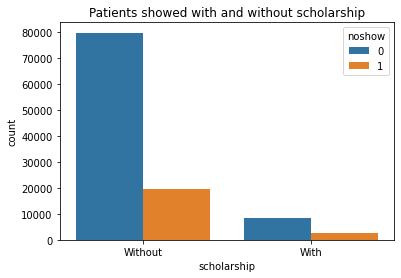

```python
#Plot graph of patients with and without scholarship that showed up and not
plotCountPlot(df.scholarship,df.noshow,"Patients showed with and without scholarship",['Without','With'])
```

**This graph shows that in either case, with and without scholarship, greater number of individuals showed up. Very large number of people were without scholarship. We need to investigate this factor more.**

```
scholarship
0    80.198438
1    76.233515
dtype: float64
```

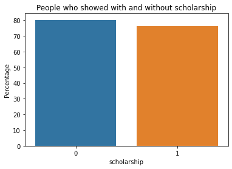

```python
#Find percentage of patients who showed up, grouped based on the scholarship
df_scholarship_ratio= df[df.noshow == 0].groupby(['scholarship']).size()/df.groupby(['scholarship']).size()*100
print(df_scholarship_ratio)

#Plot the results
plotBar(df_scholarship_ratio,'People who showed with and without scholarship')
```

**This graph shows that greater proportion of individuals showed up when they didnot have scholarship (around 80%) as compared to when they did have (around 76%).** **So this factor can be used to predict wether the patient will show up or not**

**Sms Received**

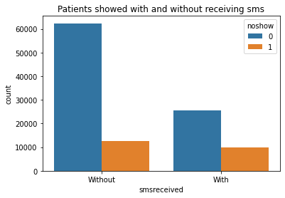

```python
#Plot graph of patients with and without receiving the sms that showed up and not
plotCountPlot(df.smsreceived,df.noshow,"Patients showed with and without receiving sms",['Without','With'])
```

```
smsreceived
0    83.307961
1    72.413501
dtype: float64
```

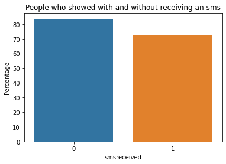

```python
#Find percentage of patients who showed up, grouped based on sms received
df_smsreceived_ratio= df[df.noshow == 0].groupby(['smsreceived']).size()/df.groupby(['smsreceived']).size()*100
print(df_smsreceived_ratio)

#Plot the results
plotBar(df_smsreceived_ratio,'People who showed with and without receiving an sms')
```

**This graph shows that greater number of individuals showed up when they didnot receive a message (83%) as compared to when they did(73%)**. **If assumed this is a reminder message then its opposite to what is suspected as people receiving a reminder must show up more.** **But this factor has a strong relationship so can be used to predict whether the patient will show up or not**

**Diabetes**

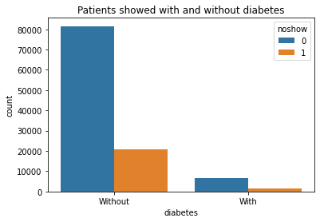

```python
#Plot graph of patients with and without diabetes that showed up and not
plotCountPlot(df.diabetes,df.noshow,"Patients showed with and without diabetes",['Without','With'])
```

```
diabetes
0    79.639719
1    82.000000
dtype: float64
```

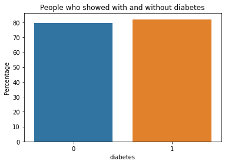

```python
#Find percentage of patients who showed up, grouped based on the diabetes
df_diabetes_ratio= df[df.noshow == 0].groupby(['diabetes']).size()/df.groupby(['diabetes']).size()*100
print(df_diabetes_ratio)

#Plot the results
plotBar(df_diabetes_ratio,'People who showed with and without diabetes')
```

**This graph shows that a greater number of people showed up if they had diabetes (around 82%) instead of those without (around 79%). So it has a small effect on determining whether patient shows up or not**

**Age**

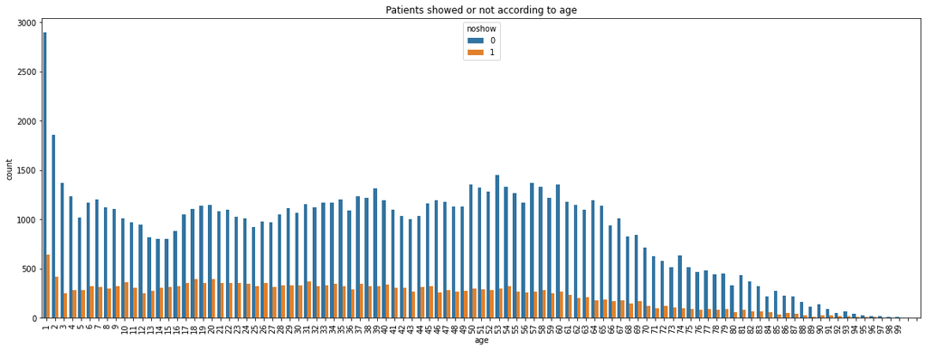

```python
#Plot graph for all ages, whether the patients showed up or not
plt.figure(figsize=(20,7))
plt.xticks(rotation=90)
r= range(1, df.age.max())
plotCountPlot(df.age, df.noshow,"Patients showed or not according to age",r)
```

```python
#Find percentage of patients of each age which showed up
df_age_ratio = df[df.noshow == 0].groupby(['age']).size()/df.groupby(['age']).size()*100
```

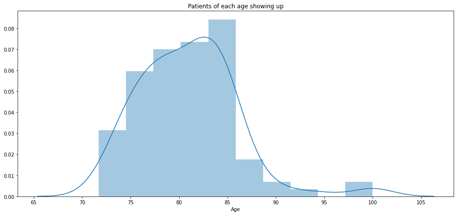

```python
#Plot the distribution plot for the patients of each age showing up
plt.figure(figsize=(16,7))
ax=sns.distplot(df_age_ratio, norm_hist=True);
ax.set_title('Patients of each age showing up');
ax.set_xlabel('Age');
```

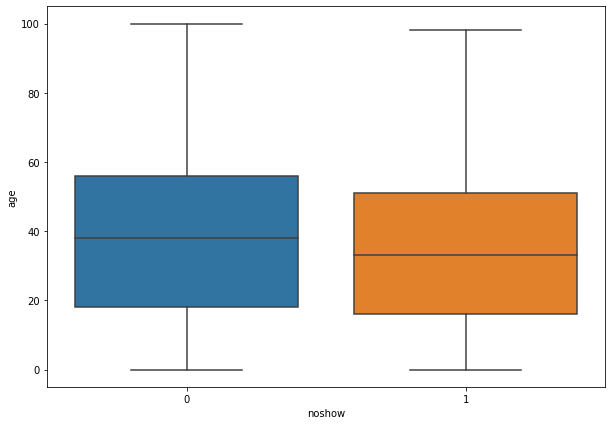

```python
plt.figure(figsize=(10,7))
ax = sns.boxplot(x="noshow",y='age', data=df)
```

**The age of those who didnot show up is shifted more downwards. Though modestly, age does seem to corelate with showing up.**

**We can divide the ages into age categories/groups and see the proportion of each group that showed up for better comparison and prediction**

```
agegroup
adults      79.688524
children    79.038627
elderly     84.570312
infants     81.944052
teen        73.980956
dtype: float64
```

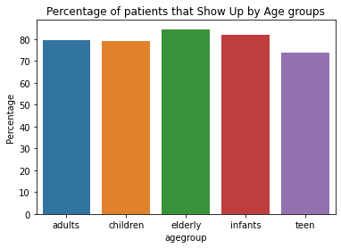

```python
#Divide the ages into various age groups and create a new column, 'agegroup'
conditions = [
    (df['age'] <1),
    (df['age'] >0 ) & (df.age < 13),
    (df.age >12)& (df.age<20),
    (df.age>19)& (df.age<65),
    (df.age>64)
    ]
groups = ['infants', 'children', 'teen','adults','elderly']

#Create new column, 'agegroup' for these categories
df['agegroup'] = np.select(conditions, groups, default='black')
df.agegroup.value_counts()

#Find percentage of patients in each age group that showed up
df_agegroup_ratio= df[df.noshow == 0].groupby(['agegroup']).size()/df.groupby(['agegroup']).size()*100
print(df_agegroup_ratio)

#Plot the results
plotBar(df_agegroup_ratio,"Percentage of patients that Show Up by Age groups")
```

**This graph gives a clearer picture of the results as we can now see that teens have the least probability of showing up (around 74%) as compared to all the other age groups.**

**Elderly(around 84%) had the most probability, then infants (around 82%), then adults (around 80%), then children (around 79%) and last teens(around 74%).**

**So depending on the age group, we can predict the chances of the patient showing up**.

**Appointment Day**

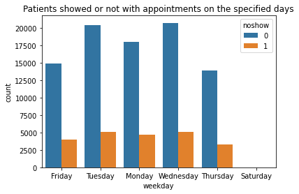

```python
#Plot graph for all days, whether the patients showed up or not
plotCountPlot(df.weekday,df.noshow,"Patients showed or not with appointments on the specified days",df.weekday.unique())
```

```
weekday
Friday       78.755794
Monday       79.361439
Saturday     76.923077
Thursday     80.637853
Tuesday      79.924168
Wednesday    80.312887
dtype: float64
```

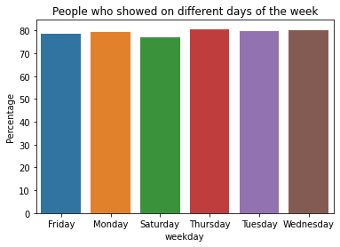

```python
#Find percentage of patients that showed up on each day of the week
df_weekday_ratio= df[df.noshow == 0].groupby(['weekday']).size()/df.groupby(['weekday']).size()*100
print(df_weekday_ratio)

#Plot the results
plotBar(df_weekday_ratio,'People who showed on different days of the week')
```

**This graph shows that approximately same percentage of people showed up during the weekdays (around 79-80%).**

**But no appointment was made for Sunday and for those made on Saturday, 76% patients showed up which shows that people tend to not visit the doctor on weekends.**

**Though there isn't a very significant difference between the results on different days of the week so it might not be a very strong factor to predict.**

```
gender  weekday
F       Friday       78.712992
        Monday       78.879487
        Saturday     75.862069
        Thursday     80.643417
        Tuesday      79.736389
        Wednesday    80.450145
M       Friday       78.833854
        Monday       80.241835
        Saturday     80.000000
        Thursday     80.627759
        Tuesday      80.286041
        Wednesday    80.055648
Name: noshow, dtype: float64
```

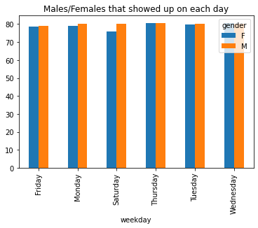

```python
#Find percentage of patients who showed up categorised by both gender and days
df_gender_day_ratio=df[df.noshow == 0].groupby(['gender','weekday'])['noshow'].count()/df.groupby(['gender','weekday'])['noshow'].count()*100
print(df_gender_day_ratio)

#Plot the results
df_gender_day_ratio.unstack('gender').plot.bar().set_title('Males/Females that showed up on each day')
```

**Neighbourhood**

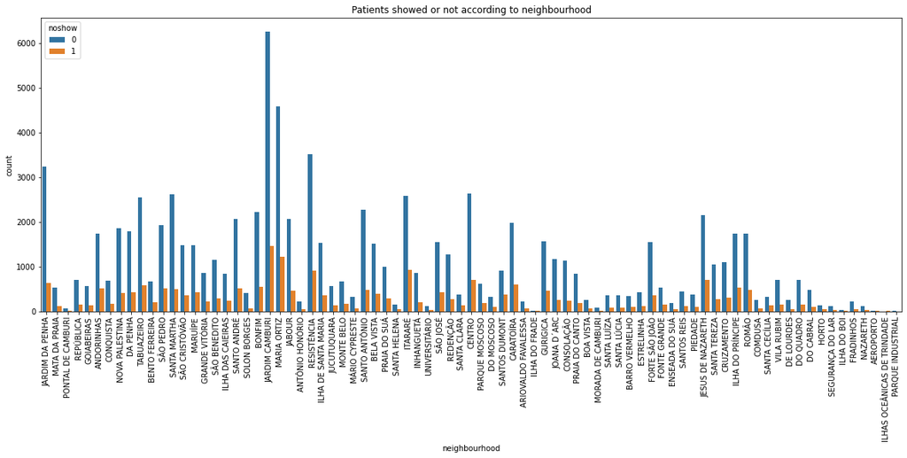

```python
#Plot graph for patients that showed up and didnot show up in various neighbourhoods
plt.figure(figsize=(20,7))
plt.xticks(rotation=90)
plotCountPlot(df.neighbourhood, df.noshow,"Patients showed or not according to neighbourhood",df.neighbourhood.unique())
```

```python
#Find percentage of patients that showed up from each neighbourhood
df_neighbourhood_ratio = df[df.noshow == 0].groupby(['neighbourhood']).size()/df.groupby(['neighbourhood']).size()*100
```

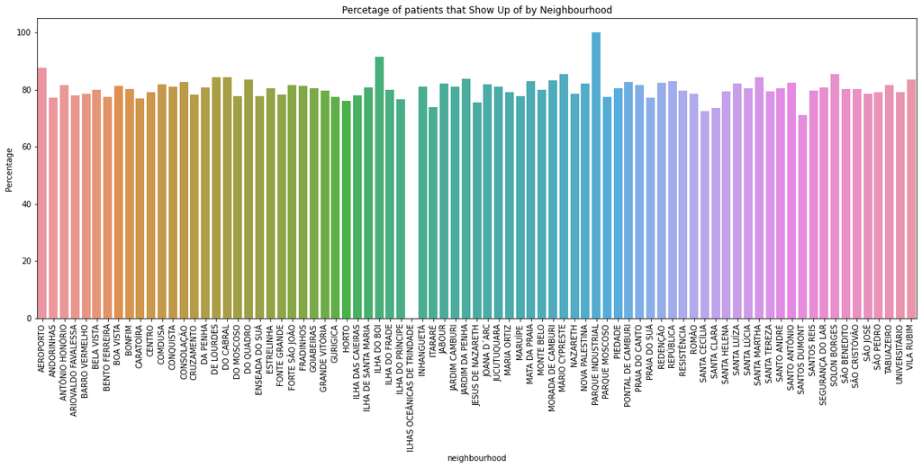

```python
#Plot graph to see proportion of patients showing up from each neighbourhood
plt.figure(figsize=(20,7))
plt.xticks(rotation=90)
plotBar(df_neighbourhood_ratio,"Percetage of patients that Show Up of by Neighbourhood")
```

**With this, we cannot make any concrete distinctions regarding neighbourhood having a significant impact on the chances of patients showing up except for one that had 0 patient and one having the most percentage of patients showing up,'Parque industrial'**.

**Handicap**

```python
#Find percentage of patients that showed up by handicap condition
df_handicap_ratio = df[df.noshow == 0].groupby(['handicap']).size()/df.groupby(['handicap']).size()*100
print(df_handicap_ratio)
```

```
handicap
0    79.76395
1    82.18842
dtype: float64
```

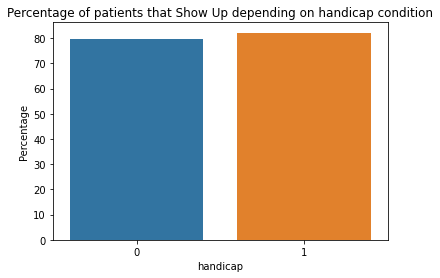

```python
#Plot graph of results
plotBar(df_handicap_ratio,"Percentage of patients that Show Up depending on handicap condition")
```

**More patients showed up when they were handicapped but it isnt a very significant difference**

**Multiple variable (2d) explorations**

```python
#Function to find and plot graph to investigate effect of multiple variables on percentage of people showing up
def show_gender_variable(variable,v):
  #find percentage of patients who show up based on gender and any other independent variable
  ratio= df[df.noshow == 0].groupby([v,variable])['noshow'].count()/df.groupby([v,variable])['noshow'].count()*100

  #Plot the results
  ratio.unstack(v).plot.bar().set_ylabel('percentage')
```

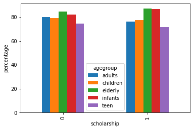

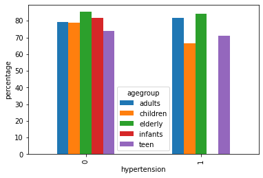

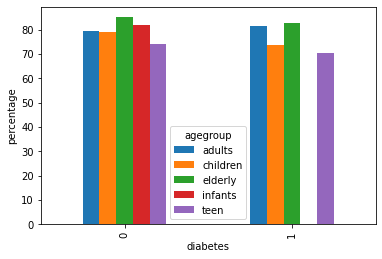

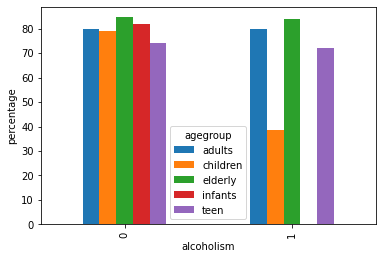

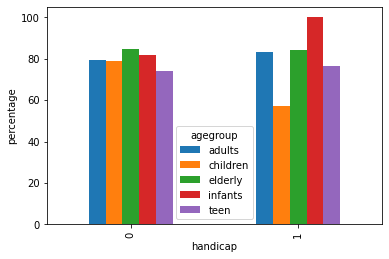

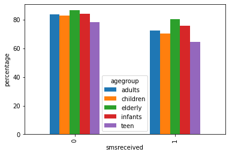

```python
# Apply function show_gender_variable() for each age group to column names 'diabetes','hypertension','alcoholism', 'smsreceived','scholarship'
df.apply(lambda x: show_gender_variable(x,'agegroup') if x.name in ['diabetes','hypertension','alcoholism', 'smsreceived','scholarship','handicap'] else None);
```

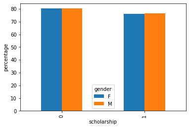

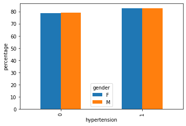

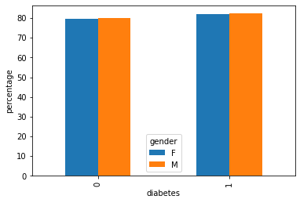

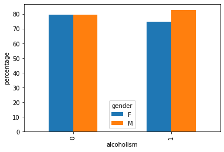

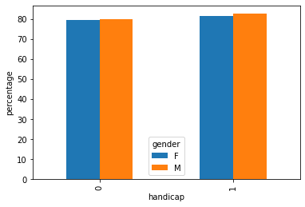

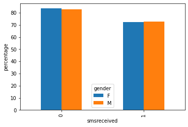

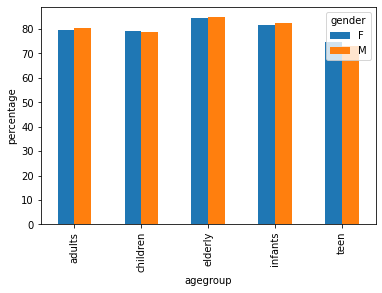

```python
# Apply function show_gender_variable() for both males and females to column names 'diabetes','hypertension','alcoholism', 'smsreceived','scholarship'
df.apply(lambda x: show_gender_variable(x,'gender') if x.name in ['agegroup','diabetes','hypertension','alcoholism', 'smsreceived','scholarship','handicap'] else None);
```

**Generally males tend to show up more than females except in case of teens and children**

### Research Question 2

**Will waiting time (difference between the day appointment was scheduled and when it actually was) impact the chances of people showing up?**

We will address this question by computing difference between the two variables(scheduled day and appointment day) and then seeing its trend with no show variable through graph.

**Waiting time between the day appointment was scheduled and the actual appointment day**

```python
#Calculate the number of days between when appointment is made and when appointment actually is and add it to a new column in dataframe
df['waiting_time']= df['appointmentday']-df['scheduledday']
df['waiting_time'].head()
```

```
0   0 days
1   0 days
2   0 days
3   0 days
4   0 days
Name: waiting_time, dtype: timedelta64[ns]
```

```python
#Restructure waiting_time column to keep only the numbers and in int datatype
df['waiting_time']=df['waiting_time'].astype(str).apply(lambda x: x.split(" ")[0]).astype(int)
df.head()
```

|  | gender | scheduledday | appointmentday | age | neighbourhood | scholarship | hypertension | diabetes | alcoholism | handicap | smsreceived | noshow | weekday | agegroup | waiting_time |
| --- | --- | --- | --- | --- | --- | --- | --- | --- | --- | --- | --- | --- | --- | --- | --- |
| 0 | F | 2016-04-29 | 2016-04-29 | 62 | JARDIM DA PENHA | 0 | 1 | 0 | 0 | 0 | 0 | 0 | Friday | adults | 0 |
| 1 | M | 2016-04-29 | 2016-04-29 | 56 | JARDIM DA PENHA | 0 | 0 | 0 | 0 | 0 | 0 | 0 | Friday | adults | 0 |
| 2 | F | 2016-04-29 | 2016-04-29 | 62 | MATA DA PRAIA | 0 | 0 | 0 | 0 | 0 | 0 | 0 | Friday | adults | 0 |
| 3 | F | 2016-04-29 | 2016-04-29 | 8 | PONTAL DE CAMBURI | 0 | 0 | 0 | 0 | 0 | 0 | 0 | Friday | children | 0 |
| 4 | F | 2016-04-29 | 2016-04-29 | 56 | JARDIM DA PENHA | 0 | 1 | 1 | 0 | 0 | 0 | 0 | Friday | adults | 0 |

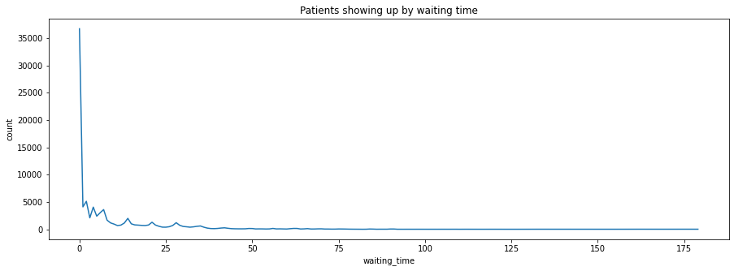

```python
#Number of patients which showed up depending on the waiting time interval
df_waiting_ratio = df[df.noshow == 0].groupby(['waiting_time'])['noshow'].count()

#Plot the results
ax= df_waiting_ratio.plot(kind='line', figsize=(15,5));
ax.set_title('Patients showing up by waiting time');
ax.set_ylabel('count');
```

**Most patients showed up when the appointment was on the same day as scheduled**

## Conclusions

My analysis revealed that:

Patients with the states diseases (hypertension, diabetes, handicapped) showed up more as compared to those without the diseases.

Alcoholism didnot effect the chances of patients showing up.

Elderly people showed up the most among age groups.

People upon not receiving the sms showed up more than those receiving.

People without the scholarship showed up more.

Gender has no influence on proportion of shows/no-shows.

## Limitations

The analysis is limited to visualisation through graphs;only seeing the trends and value distributions. Since no statistical tests have been performed, we cannot draw any causations.